# Covid-19 SIR Modeling Malaysia

Wan Nor Arifin (USM), Chan Weng Howe (UTM)

Fri, 30 Jul 2021 3:24:36 PM

## Description

This SIR model is modeled by finding the best parameters that fit to Covid-19 Malaysian data up to Fri, 30 Jul 2021.

The SIR model is defined by the following set of ordinary differential equations (Ref: Wikipedia):

$$\frac{dS}{dt} = -\frac{\beta IS}{N} \\
\frac{dI}{dt} = \frac{\beta IS}{N} - \gamma I \\
\frac{dR}{dt} = \gamma I$$
where $S$ = Susceptible population, $I$ = Infected (active), $R$ = Recovered (recover + death), and $N = S(t) + I(t) + R(t)$. $\gamma$ is defined as $\frac{1}{T_r}$, where $T_r$ = time until recovery, which can be obtained from clinical observation. $\beta$ is defines as $\frac{1}{T_c}$, where $T_c$ = time between contacts.

The basic reproduction number, $R_0$ is defined as:

$$R_0 = \frac{\beta}{\gamma}$$
$R_0$ can also be seen as $\frac{T_r}{T_c}$, i.e. the number of contacts before someone recovers, during which he is infectious.

Apart from finding the $\beta$ and $\gamma$ parameter values, experts are concerned about the number of susceptible individuals. Thus, the model is also iterated over decreasing number of initial susceptible individuals ($n$) to find this optimal $n$.

To fit the model to the data, the following weighted loss function is defined, extending the basic residual sum of squares (RSS) formulation:

$$RSS = w_1\sum_{i=1}^t(I_i - \hat I_i)^2 + w_2\sum_{i=1}^t(R_i - \hat R_i)^2 + w_3\sum_{i=1}^t([I_i + R_i] - [\hat I_i + \hat R_i])^2$$
where $w_1$, $w_2$ and $w_3$ allow adjustment of weightage given to $I$, $R$ respectively to balance the model fit. We are inclined to give more weight to $I$ through $w_1$ and $I + R$ through $w_3$.

Here, given the limitation of the optimization, one might argue that the $S$ found might instead be $E$ in SEIR model. This could be explored further in SEIR model, by allowing incubation period in the model. This is beyond the present SIR model to optimize.

## Libraries

```r
library(tidyverse)
library(deSolve)
library(lubridate)
library(ggpubr)
library(plotly)
```

## Data

Sourced from local datasets.

```r
# mys_data = read_csv("https://wnarifin.github.io/covid-19-malaysia/covid-19_my_full.csv") %>% select(1:11) %>% rename(Date = "date")
mys_data = read_csv("covid-19_my_full.csv") %>% select(1:11)  %>% rename(Date = "date")  # comment out to use local data
# rename date to Date for compatibility with original codes

# add active variable
mys_data$active = with(mys_data, total_cases - total_deaths - total_recover)
names(mys_data)
```

```
##  [1] "Date"           "location"       "new_cases"      "new_deaths"
##  [5] "total_cases"    "total_deaths"   "recover"        "total_recover"
##  [9] "icu"            "support"        "imported_cases" "active"
```

## Functions

```r
# SIR model
# S - Susceptible, I - Infected, R - Removed (recovered + death), n - initial susceptible population
SIR = function(time, state, parameters) {
  par = as.list(c(state, parameters))
  with(par, {
    dS = (-beta * I * S) / n
    dI = ((beta * I * S) / n) - (gamma * I)
    dR = gamma * I
    list(c(dS, dI, dR))
  })
}

# RSS
RSS = function(parameters) {
  names(parameters) = c("beta","gamma")
  out = ode(y=init, times=Day, func=SIR, parms=parameters)
  fit1 = out[,3]
  fit2 = out[,4]
  # give weight to less well predicted curve
  w1 = 3
  w2 = 1
  w3 = 3
  # RSS Original scale
  # w1*sum((Active - fit1)^2) + w2*sum((Removed - fit2)^2) # find min RSS on original scale, weighted. Works without too much strict setting for gamma.
  w1*sum((Active - fit1)^2) + w2*sum((Removed - fit2)^2) + w3*sum(((Active+Removed) - (fit1+fit2))^2)
  # ---
  # RSS log scale
  # w1*sum((log(Active) - log(fit1))^2) + w2*sum((log(Removed) - log(fit2))^2)  # find min RSS on log scale, weighted. Needs more work on correct gamma.
  # w1*sum((log(Active) - log(fit1))^2) + w2*sum((log(Removed) - log(fit2))^2) + w3*sum((log(Active+Removed) - log(fit1+fit2))^2)
  # Give balance to prediction of small values and large values.
  # ---
  # MAPE
  # w1*(mean(abs(log(Active) - log(fit1))/log(Active)))  + w2*(mean(abs(log(Removed) - log(fit2))/log(Removed)))  # MAPE
  # w1*(mean(abs(Active - fit1)/Active) / length(fit1)) + w2*(sum(abs(Removed - fit2)/Removed)) + w3*(mean(abs((Active+Removed) - (fit1+fit2))/(Active+Removed)))
  # Intuitive, but may be problematic when denominator = 0, or error > 1 for large prediction.
}
```

## Parameters

```r
# Uncomment under each header to perform SIR for the period

# Pre MCO #
# name = "Pre MCO"
# start_date  = "2020-03-01"
# end_date    = "2020-03-17"

# MCO All -> Today #
# name = "MCO All"
# start_date  = "2020-03-18"
# end_date    = today()  # will analyze up to max available date

# MCO week 2 -> End MCO 4 # to take into account MCO effect after 1 week
# name = "MCO week 2 -> End MCO 4"
# start_date  = "2020-03-25"
# end_date    = "2020-05-03"

# MCO 1 #
# name = "MCO 1"
# start_date  = "2020-03-18"
# end_date    = "2020-03-31"

# MCO 2 #
# name = "MCO 2"
# start_date  = "2020-04-01"
# end_date    = "2020-04-14"

# MCO 3 #
# name = "MCO 3"
# start_date  = "2020-04-15"
# end_date    = "2020-04-28"

# MCO 4 #
# name = "MCO 4"
# start_date  = "2020-04-28"
# end_date    = "2020-05-03"

# CMCO #
# name = "CMCO"
# start_date  = "2020-05-04"
# end_date    = "2020-06-09"

# RMCO 1 #
# name = "RMCO 1"
# start_date  = "2020-06-10"
# end_date    = "2020-08-31"

# RMCO 2 #
# name = "RMCO 2"
# start_date  = "2020-09-01"
# end_date    = today()  # will analyze up to max available date

# Sabah Election #
# name = "Sabah Election"
# start_date  = "2020-09-26"
# end_date    = today()  # will analyze up to max available date

# Sabah Election -> MCO 2.0 # See R0 w/out MCO
# name = "Sabah Election"
# start_date  = "2020-09-26"
# end_date    = "2021-01-12"  # up to MCO 2

# Sabah Election -> Unrestricted Travel # See R0 until 2020-12-06
# name = "Sabah Election"
# start_date  = "2020-09-26"
# end_date    = "2020-12-06"  # up to MCO 2

# RMCO 2 Unrestricted Travel -> Today #
# name = "RMCO 2 Unrestricted Travel"
# start_date  = "2020-12-07"
# end_date    = today()  # will analyze up to max available date

# RMCO 2 Unrestricted Travel -> MCO 2.0 # See R0 w/out MCO
# name = "RMCO 2 Unrestricted Travel"
# start_date  = "2020-12-07"
# end_date    = "2021-01-12"  # up to MCO 2

# MCO 2.0 #
# name = "MCO 2"
# start_date  = "2021-01-13"
# end_date    = today()  # will analyze up to max available date

# Opening of school
# Pre-school-std 2 1-3-21
# Std 3 - 6 8-3-21
# Secondary school 4-4-21
name = "Secondary School Reopened"
# start_date  = "2021-03-01"  # even too early, active cases going down
# start_date  = "2021-03-08"  # too early, active cases going down
start_date  = "2021-04-04"  # notable increase in cases, esp in Kelantan
end_date    = today()  # will analyze up to max available date

# Basic info from data
Infected   = mys_data %>% filter(Date>=ymd(start_date), Date<=ymd(end_date)) %>% pull(total_cases)
Recovered  = mys_data %>% filter(Date>=ymd(start_date), Date<=ymd(end_date)) %>% pull(total_recover)
Death      = mys_data %>% filter(Date>=ymd(start_date), Date<=ymd(end_date)) %>% pull(total_deaths)
Active     = Infected - Recovered - Death
Removed    = Recovered + Death
Date       = mys_data %>% filter(Date>=ymd(start_date), Date<=ymd(end_date)) %>% pull(Date)
Day        = 1:(length(Date))
```

## Run Optimization for SIR model

```r
# SIR parameters
# parameters_values = c(1/2, 1/14)  # set reasonable start, R0 = 7
# parameters_values_lower = c(1/100, 1/42)  # days recover max 6 weeks
# parameters_values_lower = c(1/100, 1/18.5)  # setting for log scale, days recover 6 weeks, reduce bound bcs not many severe, observed show quick recovery
# parameters_values_upper = c(1, 1/11)  # updated to min 11 days
# based on previous models in paper 1 betas (0.273, 0.152) gammas (0.033, 0.053)
parameters_values = c(0.273, 0.033)
parameters_values_lower = c(0.1, 0.01)
# parameters_values_upper = c(0.35, 0.07)  # max gamma 0.07 i.e. 14 days
parameters_values_upper = c(1, 0.07)  # max gamma 0.07 i.e. 14 days
# parameters_values_upper = c(0.5, 0.1)  # allows freedom in parameter space exploration, gamma 1/10
# cannot allow this bcs it will never converge as N cycles between 32mil (odd max step) & 64mil (even max step)!

# Placeholder to find optimal susceptible population
max_step = 7   # 7 seems sufficient
N_in_steps = data.frame(step=1:max_step, N=rep(NA,max_step), Loc=rep(NA,max_step))

# Initial values
N           = 32.68E6/4  # 4th quarter, 2019
Opt_min_loc = 1  # Optimum minimum n location in output vector
step_i      = 1  # initialize step

# Steps
for (step_i in 1:max_step) {
  cat("=== Step ", step_i, ": Finding optimal values of beta, gamma and n ===\n", sep ="")
  N = N[Opt_min_loc]  # Susceptible population from previous Step
  if (N > 32.68E6) {N = 32.68E6/4}  # avoid N > Malaysian Population
  # initial susceptible population of Malaysia
  p_start = 0.05
  p_end = 4  # max p of population, also include up direction
  p_step = 0.05
  susceptible = seq(p_start, p_end, p_step)
  N = N * susceptible
  inits = data.frame(S=N-Infected[1]-Recovered[1]-Death[1], I=Infected[1]-Death[1]-Recovered[1], R=Recovered[1]+Death[1])
  Opts = vector("list", length(N))
  for (i in 1:length(N)) {
    n = N[i]
    init = setNames(as.numeric(inits[i,]), c("S", "I", "R"))
    Opt_ = optim(parameters_values, RSS, method = "L-BFGS-B", lower = parameters_values_lower, upper = parameters_values_upper)
    Opts[i]  = list(Opt_)
  }
  Opt_value = sapply(Opts, function(x) x$value)
  Opt_min_loc = which(Opt_value == min(Opt_value))
  N_in_steps[step_i, "N"] = N[Opt_min_loc]
  N_in_steps[step_i, "Loc"] = Opt_min_loc
  cat("=== Found n = ", N[Opt_min_loc], " at location ", Opt_min_loc, " in vector N ===\n\n", sep = "")
  step_i = step_i + 1
  if (step_i == max_step + 1) {
    cat("=== Finalizing results =====\n")
    cat("============================\n")
    print(N_in_steps)
  }
}
```

```
## === Step 1: Finding optimal values of beta, gamma and n ===
## === Found n = 2859500 at location 7 in vector N ===
##
## === Step 2: Finding optimal values of beta, gamma and n ===
## === Found n = 2716525 at location 19 in vector N ===
##
## === Step 3: Finding optimal values of beta, gamma and n ===
## === Found n = 2716525 at location 20 in vector N ===
##
## === Step 4: Finding optimal values of beta, gamma and n ===
## === Found n = 2716525 at location 20 in vector N ===
##
## === Step 5: Finding optimal values of beta, gamma and n ===
## === Found n = 2716525 at location 20 in vector N ===
##
## === Step 6: Finding optimal values of beta, gamma and n ===
## === Found n = 2716525 at location 20 in vector N ===
##
## === Step 7: Finding optimal values of beta, gamma and n ===
## === Found n = 2716525 at location 20 in vector N ===
##
## === Finalizing results =====
## ============================
##   step       N Loc
## 1    1 2859500   7
## 2    2 2716525  19
## 3    3 2716525  20
## 4    4 2716525  20
## 5    5 2716525  20
## 6    6 2716525  20
## 7    7 2716525  20
```

```r
# Saving optimized parameters
Opt = Opts[[Opt_min_loc]]
Opt$message  # make sure converge
```

```
## [1] "CONVERGENCE: REL_REDUCTION_OF_F <= FACTR*EPSMCH"
```

```r
Opt_par = setNames(Opt$par, c("beta", "gamma"))
R0 = (Opt_par['beta']/Opt_par['gamma']); names(R0) = "R0"
parameters_values_lower; parameters_values; parameters_values_upper  # just to check whether values in range
```

```
## [1] 0.10 0.01
```

```
## [1] 0.273 0.033
```

```
## [1] 1.00 0.07
```

```r
# Print final parameters
cat("beta = ", Opt_par[['beta']], ", infectious contact rate (/person/day)\n",
    "gamma = ", Opt_par[['gamma']], ", recovery rate (/day)\n",
    "R_0 = ", R0, " number infected/person\n",
    "Recovery days = ", 1/Opt_par[['gamma']], " days",
    sep = "")
```

```
## beta = 0.1346302, infectious contact rate (/person/day)
## gamma = 0.07, recovery rate (/day)
## R_0 = 1.923289 number infected/person
## Recovery days = 14.28571 days
```

## Fit Data

```r
# time in days for fitting
t = 1:max(Day)
n = N[Opt_min_loc]
init = setNames(as.numeric(inits[Opt_min_loc,]), c("S", "I", "R"))
# get the fitted values from our SIR model
fitted_projected = data.frame(ode(y=init, times=t, func=SIR, parms=Opt_par))
# add Date, Active, Removed
fitted_projected$Date = Date
fitted_projected$A = Active
fitted_projected$Rm = Removed
fitted_projected
```

```
##     time       S         I        R       Date      A     Rm
## 1      1 2029116  14509.00 336450.0 2021-04-04  14509 336450
## 2      2 2027635  14958.74 337481.3 2021-04-05  14278 337751
## 3      3 2026109  15421.27 338544.6 2021-04-06  14161 339168
## 4      4 2024538  15896.86 339640.6 2021-04-07  14097 340371
## 5      5 2022919  16385.84 340770.4 2021-04-08  14203 341550
## 6      6 2021252  16888.48 341934.9 2021-04-09  14805 342802
## 7      7 2019535  17405.08 343135.1 2021-04-10  15059 344058
## 8      8 2017767  17935.93 344372.0 2021-04-11  15574 345282
## 9      9 2015947  18481.33 345646.5 2021-04-12  15835 346338
## 10    10 2014074  19041.57 346959.7 2021-04-13  16300 347640
## 11    11 2012145  19616.95 348312.7 2021-04-14  16696 349133
## 12    12 2010161  20207.75 349706.5 2021-04-15  17575 350402
## 13    13 2008119  20814.28 351142.1 2021-04-16  18600 351928
## 14    14 2006017  21436.80 352620.8 2021-04-17  19094 353765
```

[output cut: 103 more lines]

# Fit measure, original scales

```r
# log scale
# tss1 = sum((log(fitted_projected$A) - mean(log(fitted_projected$A)))^2); tss1
# rss1 = sum((log(fitted_projected$A) - log(fitted_projected$I))^2); rss1
# R2_1 = 1 - (rss1 / tss1); R2_1
# tss2 = sum((log(fitted_projected$Rm) - mean(log(fitted_projected$Rm)))^2); tss2
# rss2 = sum((log(fitted_projected$Rm) - log(fitted_projected$R))^2); rss2
# R2_2 = 1 - (rss2 / tss2); R2_2
# mape1 = sum(abs(log(fitted_projected$A) - log(fitted_projected$I))/log(fitted_projected$A)) / length(fitted_projected$A); mape1
# mape2 = sum(abs(log(fitted_projected$Rm) - log(fitted_projected$R))/log(fitted_projected$Rm)) / length(fitted_projected$Rm); mape2
# original scale
tss1 = sum((fitted_projected$A - mean(fitted_projected$A))^2); tss1
```

```
## [1] 181269523113
```

```r
rss1 = sum((fitted_projected$A - fitted_projected$I)^2); rss1
```

```
## [1] 57022729369
```

```r
R2_1 = 1 - (rss1 / tss1); R2_1
```

```
## [1] 0.6854257
```

```r
tss2 = sum((fitted_projected$Rm - mean(fitted_projected$Rm))^2); tss2
```

```
## [1] 3.307845e+12
```

```r
rss2 = sum((fitted_projected$Rm - fitted_projected$R)^2); rss2
```

```
## [1] 36179418452
```

```r
R2_2 = 1 - (rss2 / tss2); R2_2
```

```
## [1] 0.9890625
```

```r
rmse1 = sqrt(mean((fitted_projected$A - fitted_projected$I)^2)); rmse1
```

```
## [1] 22076.54
```

```r
rmse2 = sqrt(mean((fitted_projected$Rm - fitted_projected$R)^2)); rmse2
```

```
## [1] 17584.82
```

```r
mape1 = mean(abs(fitted_projected$A - fitted_projected$I)/fitted_projected$A); mape1
```

```
## [1] 0.2168597
```

```r
mape2 = mean(abs(fitted_projected$Rm - fitted_projected$R)/fitted_projected$Rm); mape2
```

```
## [1] 0.02198104
```

# Plots

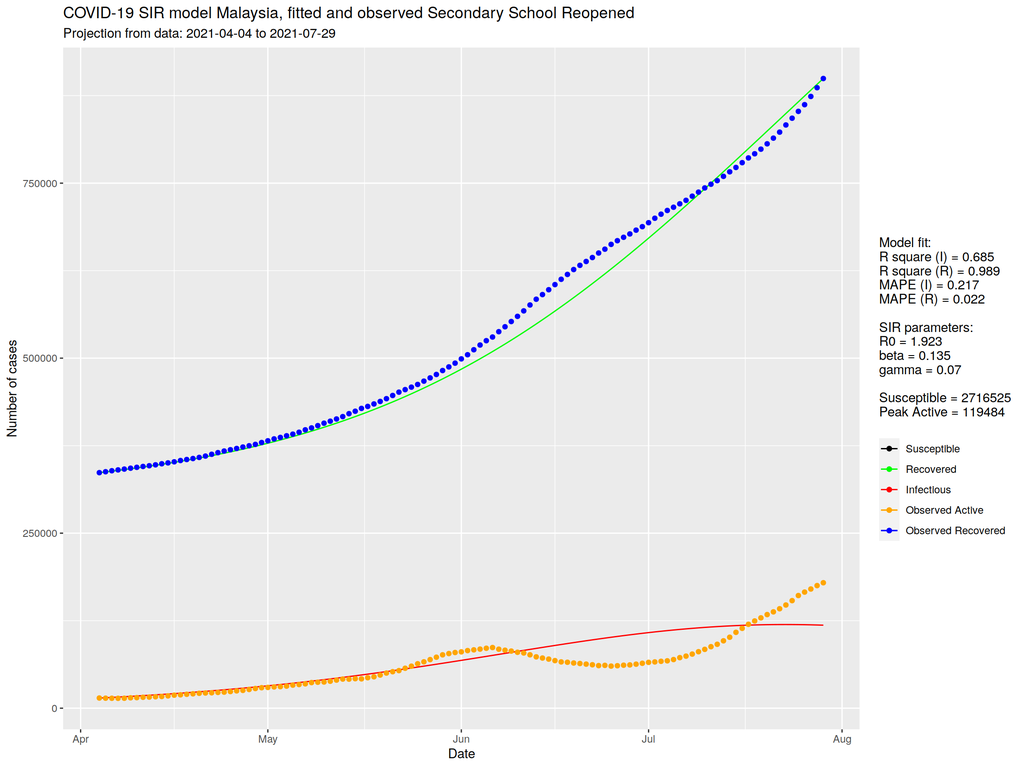

```r
# color settings
colors = c("Susceptible" = "black", "Recovered" = "green", "Infectious" = "red",
           "Observed Active" = "orange", "Observed Recovered" = "blue")

# plot fit the data
fitplot1 = ggplot(fitted_projected, aes(x = Date)) + geom_line(aes(y = I, color = "Infectious")) +
  geom_point(aes(y = A, color = "Observed Active")) + geom_line(aes(y = R, color = "Recovered")) +
  geom_point(aes(y = Rm, color = "Observed Recovered")) +
  labs(y = "Number of cases", title = paste("COVID-19 SIR model Malaysia, fitted and observed", name),
       subtitle = paste("Projection from data:", start_date, "to", fitted_projected$Date[max(Day)]),
       color = paste0("Model fit:\n",
                      "R square (I) = ", round(R2_1,3), "\n",
                      "R square (R) = ", round(R2_2,3), "\n",
                      "MAPE (I) = ", round(mape1,3), "\n",
                      "MAPE (R) = ", round(mape2,3), "\n\n",
                      "SIR parameters:\n",
                      "R0 = ", round(R0, 3), "\n",
                      "beta = ", round(Opt_par[1], 3), "\n",
                      "gamma = ", round(Opt_par[2], 3), "\n\n",
                      "Susceptible = ", round(n), "\n",
                      "Peak Active = ", round(max(fitted_projected$I)), "\n")) +
  scale_colour_manual(values = colors)
fitplot1
```

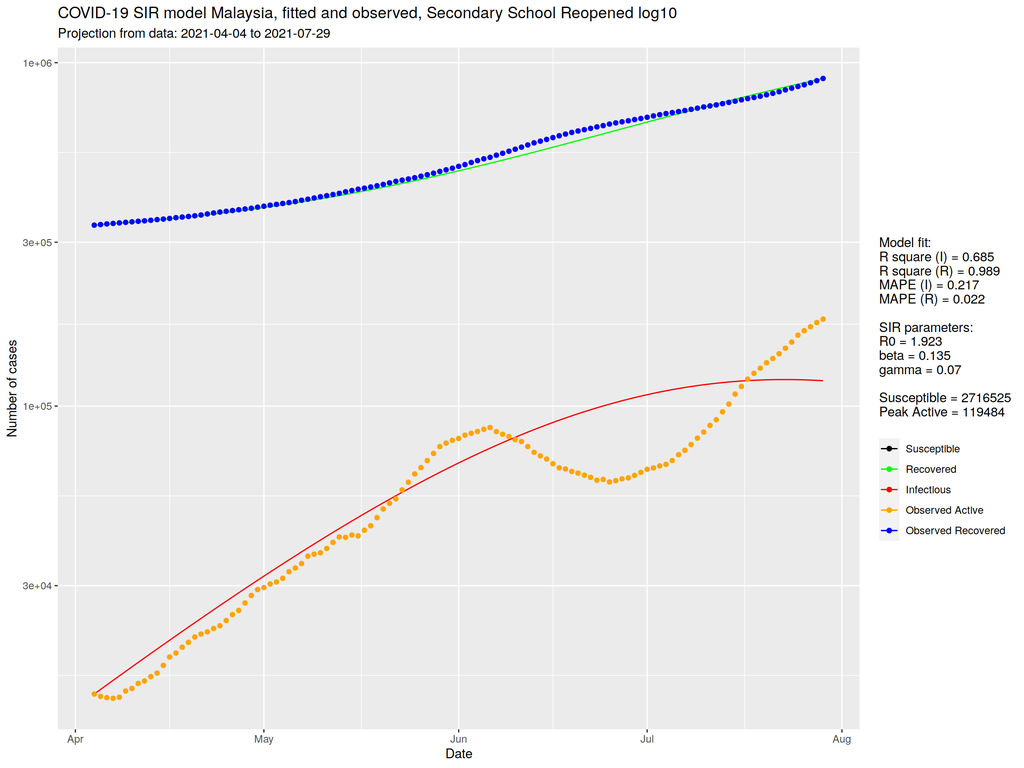

```r
# uncomment ggsave line to save plot in png format, make sure folder "plots_srn" is created
# ggsave(paste0("plots_srn/fit", name, ".png"), width = 12, height = 9)

# plot fit the data, in log10
fitplot1_log = ggplot(fitted_projected, aes(x = Date)) + geom_line(aes(y = I, color = "Infectious")) +
  geom_point(aes(y = A, color = "Observed Active")) + geom_line(aes(y = R, color = "Recovered")) +
  geom_point(aes(y = Rm, color = "Observed Recovered")) + scale_y_log10() +
  labs(y = "Number of cases", title = paste("COVID-19 SIR model Malaysia, fitted and observed,", name, "log10"),
       subtitle = paste("Projection from data:", start_date, "to", fitted_projected$Date[max(Day)]),
       color = paste0("Model fit:\n",
                      "R square (I) = ", round(R2_1,3), "\n",
                      "R square (R) = ", round(R2_2,3), "\n",
                      "MAPE (I) = ", round(mape1,3), "\n",
                      "MAPE (R) = ", round(mape2,3), "\n\n",
                      "SIR parameters:\n",
                      "R0 = ", round(R0, 3), "\n",
                      "beta = ", round(Opt_par[1], 3), "\n",
                      "gamma = ", round(Opt_par[2], 3), "\n\n",
                      "Susceptible = ", round(n), "\n",
                      "Peak Active = ", round(max(fitted_projected$I)), "\n")) +
  scale_colour_manual(values = colors)
fitplot1_log
```

```r
# uncomment ggsave line to save plot in png format, make sure folder "plots_srn" is created
# ggsave(paste0("plots_srn/fit", name, "_log.png"), width = 12, height = 9)
```

## Projected Data

```r
# last date to project
last_date = "2022-06-30"
# time in days for predictions
t = 1:as.integer(ymd(last_date) + 1 - ymd(start_date))
# get the fitted values from our SIR model
fitted_projected = data.frame(ode(y=init, times=t, func=SIR, parms=Opt_par))
# add add Date, Active, Removed
fitted_projected$Date = ymd(start_date) + days(t - 1)
fitted_projected$A = c(Active, rep(NA, length(t) - length(Active)))
fitted_projected$Rm = c(Removed, rep(NA, length(t) - length(Active)))
head(fitted_projected, 10); tail(fitted_projected, 10)
```

```
##    time       S        I        R       Date     A     Rm
## 1     1 2029116 14509.00 336450.0 2021-04-04 14509 336450
## 2     2 2027635 14958.74 337481.3 2021-04-05 14278 337751
## 3     3 2026109 15421.27 338544.6 2021-04-06 14161 339168
## 4     4 2024538 15896.86 339640.6 2021-04-07 14097 340371
## 5     5 2022919 16385.84 340770.4 2021-04-08 14203 341550
## 6     6 2021252 16888.48 341934.9 2021-04-09 14805 342802
## 7     7 2019535 17405.08 343135.1 2021-04-10 15059 344058
## 8     8 2017767 17935.93 344372.0 2021-04-11 15574 345282
## 9     9 2015947 18481.33 345646.5 2021-04-12 15835 346338
## 10   10 2014074 19041.57 346959.7 2021-04-13 16300 347640
```

```
##     time        S        I       R       Date  A Rm
## 444  444 908408.9 95.61234 1471570 2022-06-21 NA NA
## 445  445 908404.7 93.25356 1471577 2022-06-22 NA NA
## 446  446 908400.5 90.95296 1471584 2022-06-23 NA NA
## 447  447 908396.5 88.70909 1471590 2022-06-24 NA NA
## 448  448 908392.5 86.52057 1471596 2022-06-25 NA NA
## 449  449 908388.7 84.38602 1471602 2022-06-26 NA NA
## 450  450 908385.0 82.30412 1471608 2022-06-27 NA NA
## 451  451 908381.3 80.27357 1471613 2022-06-28 NA NA
## 452  452 908377.7 78.29310 1471619 2022-06-29 NA NA
## 453  453 908374.2 76.36148 1471624 2022-06-30 NA NA
```

```r
# date of peak active cases
# max_I = which(round(fitted_projected$I) == round(max(fitted_projected$I)))  # at times this works better
max_I = which(fitted_projected$I == max(fitted_projected$I))
max_date = fitted_projected$Date[max_I]
# add cumulative infected cases
fitted_projected$total_infected = fitted_projected$I + fitted_projected$R
# predicted new cases today
new_today = (fitted_projected[fitted_projected$Date == today(), ] - fitted_projected[fitted_projected$Date == today()-1, ])$total_infected
# maximum cumulative cases, date. May add to plot.
fitted_projected$Date[min(which(round(fitted_projected$total_infected) == max(round(fitted_projected$total_infected))))]
```

```
## [1] "2022-06-30"
```

```r
fitted_projected[min(which(round(fitted_projected$total_infected) == max(round(fitted_projected$total_infected)))),]
```

```
##     time        S        I       R       Date  A Rm total_infected
## 453  453 908374.2 76.36148 1471624 2022-06-30 NA NA        1471701
```

```r
# save for later view
write.csv(fitted_projected, "fitted_sir.csv")
```

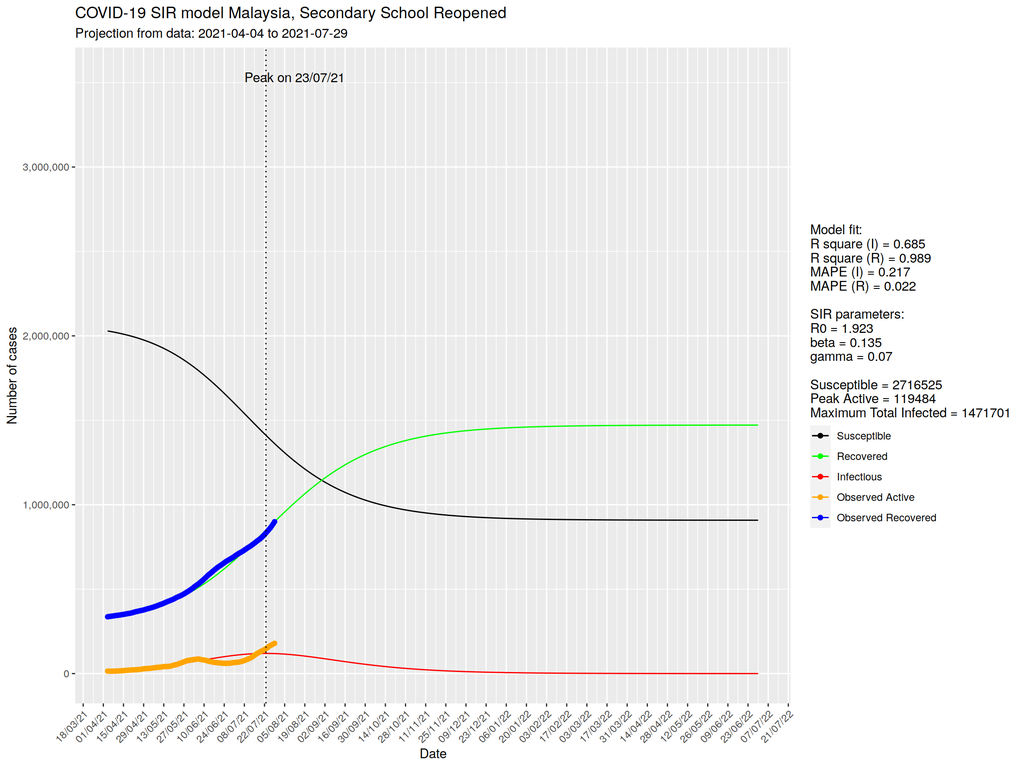

```r
# color settings
colors = c("Susceptible" = "black", "Recovered" = "green", "Infectious" = "red", "Observed Active" = "orange", "Observed Recovered" = "blue")

# plot projection data
sirplot1 = ggplot(fitted_projected, aes(x = Date)) +
  geom_line(aes(y = I, color = "Infectious")) +
  geom_line(aes(y = S, color = "Susceptible")) +
  geom_line(aes(y = R, color = "Recovered")) +
  geom_point(aes(y = A, color = "Observed Active")) +
  geom_point(aes(y = Rm, color = "Observed Recovered")) +
  scale_y_continuous(labels = scales::comma) +
  scale_x_date(date_breaks = "14 day", date_labels = "%d/%m/%y") +
  scale_colour_manual(values = colors) +
  labs(y = "Number of cases", title = paste("COVID-19 SIR model Malaysia,", name),
       subtitle = paste("Projection from data:", start_date, "to", fitted_projected$Date[max(Day)]),
       color = paste0("Model fit:\n",
                      "R square (I) = ", round(R2_1,3), "\n",
                      "R square (R) = ", round(R2_2,3), "\n",
                      "MAPE (I) = ", round(mape1,3), "\n",
                      "MAPE (R) = ", round(mape2,3), "\n\n",
                      "SIR parameters:\n",
                      "R0 = ", round(R0, 3), "\n",
                      "beta = ", round(Opt_par[1], 3), "\n",
                      "gamma = ", round(Opt_par[2], 3), "\n\n",
                      "Susceptible = ", round(n), "\n",
                      "Peak Active = ", round(max(fitted_projected$I)), "\n",
                      "Maximum Total Infected = ", round(max(fitted_projected$total_infected)))) +
  geom_vline(xintercept = as.numeric(as.Date(max_date)), linetype = "dotted") +
  annotate(geom = "text", x = as.Date(max_date)+20, y = n*1.3,
           label = paste0("Peak on ", format(max_date, "%d/%m/%y")), angle = 0) +
  # geom_vline(xintercept = as.numeric(as.Date(today())), linetype = "dotted", color = "red") +
  # annotate(geom = "text", x = as.Date(today())+25, y = n*1.2,
  #          label = paste0("Today's Prediction (", format(today(), "%d/%m/%y"), ")\n",
  #                         "Total Cases = ", round(fitted_projected[fitted_projected$Date == today(), "total_infected"]),
  #                         "\nNew Cases = ", round(new_today)), angle = 0) +
  theme(axis.text.x = element_text(angle = 45, hjust = 1))
sirplot1
```

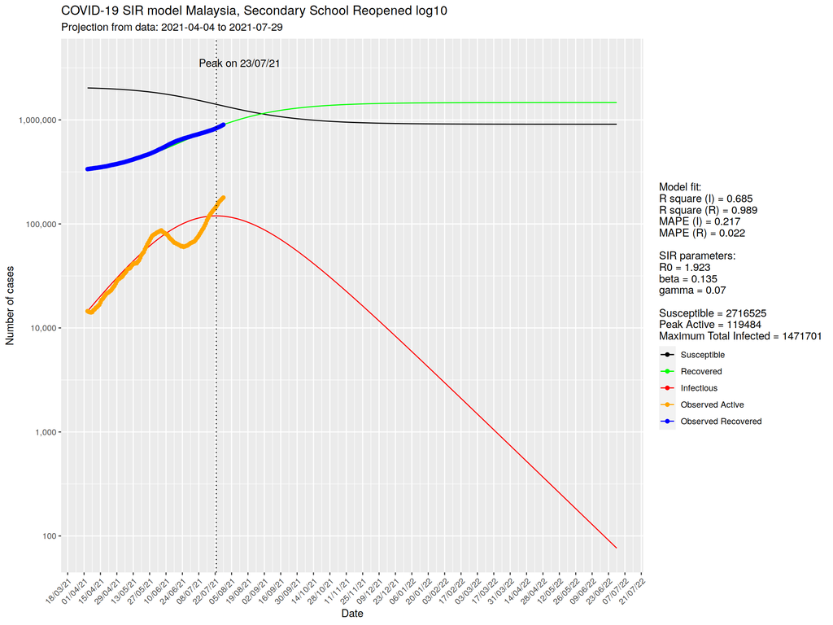

```r
# uncomment ggsave line to save plot in png format, make sure folder "plots_srn" is created
# ggsave(paste0("plots_srn/sir", name, ".png"), width = 12, height = 9)

# plot projection data, in log10
sirplot1_log = ggplot(fitted_projected, aes(x = Date)) +
  geom_line(aes(y = I, color = "Infectious")) +
  geom_line(aes(y = S, color = "Susceptible")) +
  geom_line(aes(y = R, color = "Recovered")) +
  geom_point(aes(y = A, color = "Observed Active")) +
  geom_point(aes(y = Rm, color = "Observed Recovered")) +
  scale_y_log10(labels = scales::comma) +
  scale_x_date(date_breaks = "14 day", date_labels = "%d/%m/%y") +
  scale_colour_manual(values = colors) +
  labs(y = "Number of cases", title = paste("COVID-19 SIR model Malaysia,", name, "log10"),
       subtitle = paste("Projection from data:", start_date, "to", fitted_projected$Date[max(Day)]),
       color = paste0("Model fit:\n",
                      "R square (I) = ", round(R2_1,3), "\n",
                      "R square (R) = ", round(R2_2,3), "\n",
                      "MAPE (I) = ", round(mape1,3), "\n",
                      "MAPE (R) = ", round(mape2,3), "\n\n",
                      "SIR parameters:\n",
                      "R0 = ", round(R0, 3), "\n",
                      "beta = ", round(Opt_par[1], 3), "\n",
                      "gamma = ", round(Opt_par[2], 3), "\n\n",
                      "Susceptible = ", round(n), "\n",
                      "Peak Active = ", round(max(fitted_projected$I)), "\n",
                      "Maximum Total Infected = ", round(max(fitted_projected$total_infected)))) +
  geom_vline(xintercept = as.numeric(as.Date(max_date)), linetype = "dotted") +
  annotate(geom = "text", x = as.Date(max_date)+20, y = n*1.3,
           label = paste0("Peak on ", format(max_date, "%d/%m/%y")), angle = 0) +
  # geom_vline(xintercept = as.numeric(as.Date(today())), linetype = "dotted", color = "red") +
  # annotate(geom = "text", x = as.Date(today())+25, y = n*0.7,
  #          label = paste0("Today's Prediction (", format(today(), "%d/%m/%y"), ")\n",
  #                         "Total Cases = ", round(fitted_projected[fitted_projected$Date == today(), "total_infected"]),
  #                         "\nNew Cases = ", round(new_today)), angle = 0) +
  theme(axis.text.x = element_text(angle = 45, hjust = 1))
sirplot1_log
```

```r
# uncomment ggsave line to save plot in png format, make sure folder "plots_srn" is created
# ggsave(paste0("plots_srn/sir", name, "_log.png"), width = 12, height = 9)
```

## Projection + Asymptomatic

```r
# if 5%, 50%  asymptomatic
# https://www.cebm.net/covid-19/covid-19-what-proportion-are-asymptomatic/

# 1st situation --- #
# get the fitted values from our SIR model
p_asym = .05  # China figure, 5%
n1 = n/(1-p_asym)  # inflate by %
# init = c(S=n1-Infected[1]-Recovered[1]-Death[1], I=Infected[1]-Death[1]-Recovered[1], R=Recovered[1]+Death[1])
init_pre = init  # save original value for use later
# new init
init = init_pre/(1-p_asym)
fitted_projected1 = data.frame(ode(y=init, times=t, func=SIR, parms=Opt_par))
# add a Date & Active
fitted_projected1$Date = ymd(start_date) + days(t - 1)
fitted_projected1$A = c(Active, rep(NA, length(t) - length(Active)))
fitted_projected1$Rm = c(Removed, rep(NA, length(t) - length(Active)))
head(fitted_projected1, 10); tail(fitted_projected1, 10)
```

```
##    time       S        I        R       Date     A     Rm
## 1     1 2135912 15272.63 354157.9 2021-04-04 14509 336450
## 2     2 2134266 15829.54 355246.4 2021-04-05 14278 337751
## 3     3 2132562 16405.38 356374.5 2021-04-06 14161 339168
## 4     4 2130798 17000.71 357543.6 2021-04-07 14097 340371
## 5     5 2128971 17616.07 358755.1 2021-04-08 14203 341550
## 6     6 2127080 18252.03 360010.3 2021-04-09 14805 342802
## 7     7 2125122 18909.14 361310.8 2021-04-10 15059 344058
## 8     8 2123096 19587.98 362658.1 2021-04-11 15574 345282
## 9     9 2120999 20289.12 364053.7 2021-04-12 15835 346338
## 10   10 2118830 21013.13 365499.1 2021-04-13 16300 347640
```

```
##     time        S        I       R       Date  A Rm
## 444  444 850437.8 36.57164 1654868 2022-06-21 NA NA
## 445  445 850436.3 35.56708 1654870 2022-06-22 NA NA
## 446  446 850434.9 34.59011 1654873 2022-06-23 NA NA
## 447  447 850433.4 33.63997 1654875 2022-06-24 NA NA
## 448  448 850432.0 32.71593 1654877 2022-06-25 NA NA
## 449  449 850430.7 31.81728 1654880 2022-06-26 NA NA
## 450  450 850429.3 30.94330 1654882 2022-06-27 NA NA
## 451  451 850428.0 30.09333 1654884 2022-06-28 NA NA
## 452  452 850426.8 29.26670 1654886 2022-06-29 NA NA
## 453  453 850425.6 28.46278 1654888 2022-06-30 NA NA
```

```r
# add cumulative cases
fitted_projected1$total_infected = fitted_projected1$I + fitted_projected1$R
# maximum cumulative cases, date. May add to plot.
fitted_projected1$Date[min(which(round(fitted_projected1$total_infected) == max(round(fitted_projected1$total_infected))))]
```

```
## [1] "2022-06-30"
```

```r
fitted_projected1[min(which(round(fitted_projected1$total_infected) == max(round(fitted_projected1$total_infected)))),]
```

```
##     time        S        I       R       Date  A Rm total_infected
## 453  453 850425.6 28.46278 1654888 2022-06-30 NA NA        1654917
```

```r
# --- 2nd situation --- #
# get the fitted values from our SIR model
p_asym = .5  # Iceland figure, 50%
n2 = n/(1-p_asym)  # inflate by %
# init = c(S=n2-Infected[1]-Recovered[1]-Death[1], I=Infected[1]-Death[1]-Recovered[1], R=Recovered[1]+Death[1])
# new init
init = init_pre/(1-p_asym)
fitted_projected2 = data.frame(ode(y=init, times=t, func=SIR, parms=Opt_par))
# add a Date & Active
fitted_projected2$Date = ymd(start_date) + days(t - 1)
fitted_projected2$A = c(Active, rep(NA, length(t) - length(Active)))
fitted_projected2$Rm = c(Removed, rep(NA, length(t) - length(Active)))
head(fitted_projected2, 10); tail(fitted_projected2, 10)
```

```
##    time       S        I        R       Date     A     Rm
## 1     1 4058232 29018.00 672900.0 2021-04-04 14509 336450
## 2     2 4052001 33078.71 675070.3 2021-04-05 14278 337751
## 3     3 4044911 37695.27 677544.0 2021-04-06 14161 339168
## 4     4 4036848 42940.00 680362.3 2021-04-07 14097 340371
## 5     5 4027684 48893.59 683572.1 2021-04-08 14203 341550
## 6     6 4017278 55645.71 687226.1 2021-04-09 14805 342802
## 7     7 4005471 63295.47 691383.5 2021-04-10 15059 344058
## 8     8 3992087 71951.99 696110.9 2021-04-11 15574 345282
## 9     9 3976932 81734.64 701483.0 2021-04-12 15835 346338
## 10   10 3959794 92773.17 707583.1 2021-04-13 16300 347640
```

```
##     time        S            I       R       Date  A Rm
## 444  444 272512.1 0.0003857938 4487638 2022-06-21 NA NA
## 445  445 272512.1 0.0003646029 4487638 2022-06-22 NA NA
## 446  446 272512.1 0.0003445759 4487638 2022-06-23 NA NA
## 447  447 272512.1 0.0003256489 4487638 2022-06-24 NA NA
## 448  448 272512.1 0.0003077616 4487638 2022-06-25 NA NA
## 449  449 272512.1 0.0002908568 4487638 2022-06-26 NA NA
## 450  450 272512.1 0.0002748806 4487638 2022-06-27 NA NA
## 451  451 272512.1 0.0002597819 4487638 2022-06-28 NA NA
## 452  452 272512.1 0.0002455125 4487638 2022-06-29 NA NA
## 453  453 272512.1 0.0002320270 4487638 2022-06-30 NA NA
```

```r
# add cumulative cases
fitted_projected2$total_infected = fitted_projected2$I + fitted_projected2$R
# maximum cumulative cases, date. May add to plot.
fitted_projected2$Date[min(which(round(fitted_projected2$total_infected) == max(round(fitted_projected2$total_infected))))]
```

```
## [1] "2022-01-25"
```

```r
fitted_projected2[min(which(round(fitted_projected2$total_infected) == max(round(fitted_projected2$total_infected)))),]
```

```
##     time        S        I       R       Date  A Rm total_infected
## 297  297 272512.5 1.559656 4487636 2022-01-25 NA NA        4487638
```

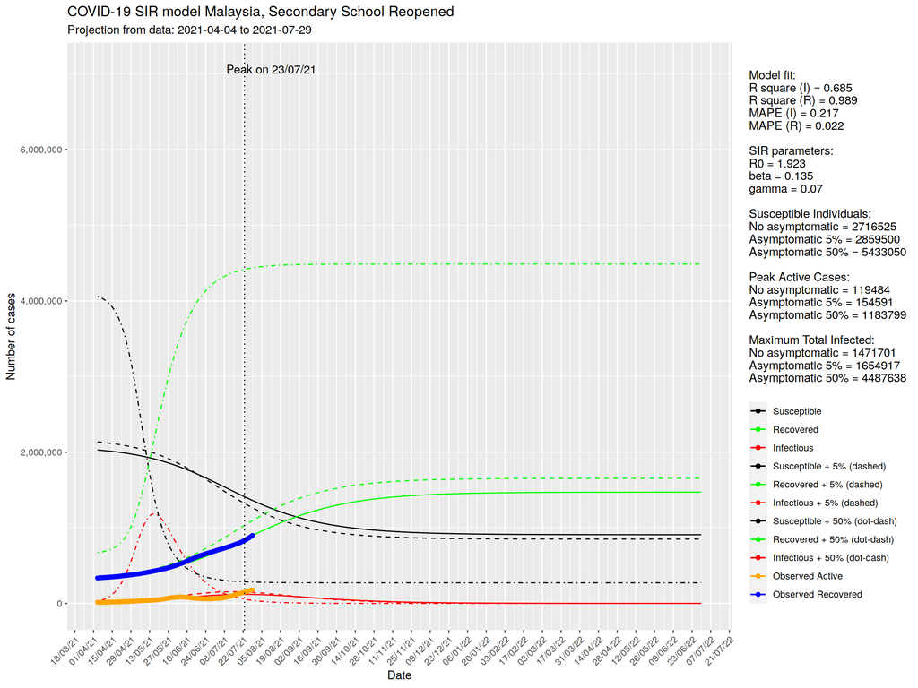

```r
# color settings
colors = c("Susceptible" = "black", "Recovered" = "green", "Infectious" = "red",
           "Susceptible + 5% (dashed)" = "black", "Recovered + 5% (dashed)" = "green", "Infectious + 5% (dashed)" = "red",
           "Susceptible + 50% (dot-dash)" = "black", "Recovered + 50% (dot-dash)" = "green", "Infectious + 50% (dot-dash)" = "red",
           "Observed Active" = "orange", "Observed Recovered" = "blue")

# plot projection data
sirplot2 = ggplot(fitted_projected, aes(x = Date)) +
  geom_line(aes(y = I, color = "Infectious")) +
  geom_line(aes(y = S, color = "Susceptible")) +
  geom_line(aes(y = R, color = "Recovered")) +
  geom_line(data=fitted_projected1, aes(y = I, color = "Infectious + 5% (dashed)"), linetype = "dashed") +
  geom_line(data=fitted_projected1, aes(y = S, color = "Susceptible + 5% (dashed)"), linetype = "dashed") +
  geom_line(data=fitted_projected1, aes(y = R, color = "Recovered + 5% (dashed)"), linetype = "dashed") +
  geom_line(data=fitted_projected2, aes(y = I, color = "Infectious + 50% (dot-dash)"), linetype = "dotdash") +
  geom_line(data=fitted_projected2, aes(y = S, color = "Susceptible + 50% (dot-dash)"), linetype = "dotdash") +
  geom_line(data=fitted_projected2, aes(y = R, color = "Recovered + 50% (dot-dash)"), linetype = "dotdash") +
  geom_point(aes(y = A, color = "Observed Active")) +
  geom_point(aes(y = Rm, color = "Observed Recovered")) +
  scale_y_continuous(labels = scales::comma) +
  scale_x_date(date_breaks = "14 day", date_labels = "%d/%m/%y") +
  scale_colour_manual(values = colors) +
  labs(y = "Number of cases", title = paste("COVID-19 SIR model Malaysia,", name),
       subtitle = paste("Projection from data:", start_date, "to", fitted_projected$Date[max(Day)]),
       color = paste0("Model fit:\n",
                      "R square (I) = ", round(R2_1,3), "\n",
                      "R square (R) = ", round(R2_2,3), "\n",
                      "MAPE (I) = ", round(mape1,3), "\n",
                      "MAPE (R) = ", round(mape2,3), "\n\n",
                      "SIR parameters:\n",
                      "R0 = ", round(R0, 3), "\n",
                      "beta = ", round(Opt_par[1], 3), "\n",
                      "gamma = ", round(Opt_par[2], 3), "\n\n",
                      "Susceptible Individuals:\n",
                      "No asymptomatic = ", round(n), "\n",
                      "Asymptomatic 5% = ", round(n1), "\n",
                      "Asymptomatic 50% = ", round(n2), "\n\n",
                      "Peak Active Cases:\n",
                      "No asymptomatic = ", round(max(fitted_projected$I)), "\n",
                      "Asymptomatic 5% = ", round(max(fitted_projected1$I)), "\n",
                      "Asymptomatic 50% = ", round(max(fitted_projected2$I)), "\n\n",
                      "Maximum Total Infected:\n",
                      "No asymptomatic = ", round(max(fitted_projected$total_infected)), "\n",
                      "Asymptomatic 5% = ", round(max(fitted_projected1$total_infected)), "\n",
                      "Asymptomatic 50% = ", round(max(fitted_projected2$total_infected)), "\n")) +
  geom_vline(xintercept = as.numeric(as.Date(max_date)), linetype = "dotted") +
  annotate(geom = "text", x = as.Date(max_date)+20, y = n2*1.3,
           label = paste0("Peak on ", format(max_date, "%d/%m/%y")), angle = 0) +
  # geom_vline(xintercept = as.numeric(as.Date(today())), linetype = "dotted", color = "red") +
  # annotate(geom = "text", x = as.Date(today())+25, y = n2*1.2,
  #          label = paste0("Today's Prediction (", format(today(), "%d/%m/%y"), ")\n",
  #                         "Total Cases = ", round(fitted_projected[fitted_projected$Date == today(), "total_infected"]),
  #                         "\nNew Cases = ", round(new_today)), angle = 0) +
  theme(axis.text.x = element_text(angle = 45, hjust = 1))
sirplot2
```

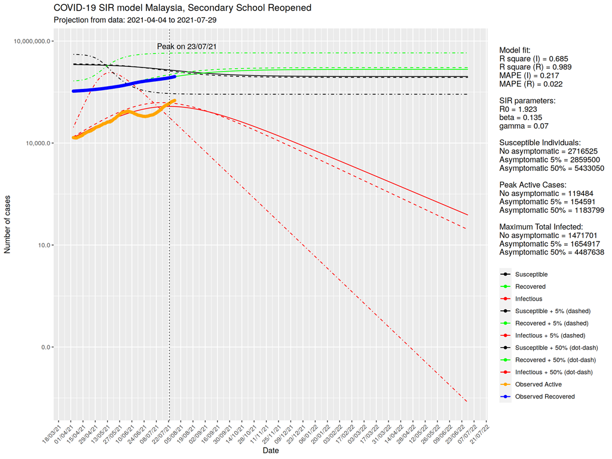

```r
# uncomment ggsave line to save plot in png format, make sure folder "plots_srn" is created
ggsave(paste0("plots_srn/sir", name, "_", fitted_projected$Date[max(Day)], "_asymp.png"), width = 12, height = 9)
# plot projection data, in log10
sirplot2_log = ggplot(fitted_projected, aes(x = Date)) +
  geom_line(aes(y = I, color = "Infectious")) +
  geom_line(aes(y = S, color = "Susceptible")) +
  geom_line(aes(y = R, color = "Recovered")) +
  geom_line(data=fitted_projected1, aes(y = I, color = "Infectious + 5% (dashed)"), linetype = "dashed") +
  geom_line(data=fitted_projected1, aes(y = S, color = "Susceptible + 5% (dashed)"), linetype = "dashed") +
  geom_line(data=fitted_projected1, aes(y = R, color = "Recovered + 5% (dashed)"), linetype = "dashed") +
  geom_line(data=fitted_projected2, aes(y = I, color = "Infectious + 50% (dot-dash)"), linetype = "dotdash") +
  geom_line(data=fitted_projected2, aes(y = S, color = "Susceptible + 50% (dot-dash)"), linetype = "dotdash") +
  geom_line(data=fitted_projected2, aes(y = R, color = "Recovered + 50% (dot-dash)"), linetype = "dotdash") +
  geom_point(aes(y = A, color = "Observed Active")) +
  geom_point(aes(y = Rm, color = "Observed Recovered")) +
  scale_y_log10(labels = scales::comma) +
  scale_x_date(date_breaks = "14 day", date_labels = "%d/%m/%y") +
  scale_colour_manual(values = colors) +
  labs(y = "Number of cases", title = paste("COVID-19 SIR model Malaysia,", name),
       subtitle = paste("Projection from data:", start_date, "to", fitted_projected$Date[max(Day)]),
       color = paste0("Model fit:\n",
                      "R square (I) = ", round(R2_1,3), "\n",
                      "R square (R) = ", round(R2_2,3), "\n",
                      "MAPE (I) = ", round(mape1,3), "\n",
                      "MAPE (R) = ", round(mape2,3), "\n\n",
                      "SIR parameters:\n",
                      "R0 = ", round(R0, 3), "\n",
                      "beta = ", round(Opt_par[1], 3), "\n",
                      "gamma = ", round(Opt_par[2], 3), "\n\n",
                      "Susceptible Individuals:\n",
                      "No asymptomatic = ", round(n), "\n",
                      "Asymptomatic 5% = ", round(n1), "\n",
                      "Asymptomatic 50% = ", round(n2), "\n\n",
                      "Peak Active Cases:\n",
                      "No asymptomatic = ", round(max(fitted_projected$I)), "\n",
                      "Asymptomatic 5% = ", round(max(fitted_projected1$I)), "\n",
                      "Asymptomatic 50% = ", round(max(fitted_projected2$I)), "\n\n",
                      "Maximum Total Infected:\n",
                      "No asymptomatic = ", round(max(fitted_projected$total_infected)), "\n",
                      "Asymptomatic 5% = ", round(max(fitted_projected1$total_infected)), "\n",
                      "Asymptomatic 50% = ", round(max(fitted_projected2$total_infected)), "\n")) +
  geom_vline(xintercept = as.numeric(as.Date(max_date)), linetype = "dotted") +
  annotate(geom = "text", x = as.Date(max_date)+20, y = n2*1.3,
           label = paste0("Peak on ", format(max_date, "%d/%m/%y")), angle = 0) +
  # geom_vline(xintercept = as.numeric(as.Date(today())), linetype = "dotted", color = "red") +
  # annotate(geom = "text", x = as.Date(today())+25, y = n2*0.7,
  #          label = paste0("Today's Prediction (", format(today(), "%d/%m/%y"), ")\n",
  #                         "Total Cases = ", round(fitted_projected[fitted_projected$Date == today(), "total_infected"]),
  #                         "\nNew Cases = ", round(new_today)), angle = 0) +
  theme(axis.text.x = element_text(angle = 45, hjust = 1))
sirplot2_log
```

```r
# uncomment ggsave line to save plot in png format, make sure folder "plots_srn" is created
ggsave(paste0("plots_srn/sir", name, "_", fitted_projected$Date[max(Day)], "_log_asymp.png"), width = 12, height = 9)
```

## Appendix

Detailed projected data.

```r
fitted_projected$new_cases = diff(c(NA, fitted_projected$total_infected))
knitr::kable(fitted_projected, format="markdown")
```

| time | S | I | R | Date | A | Rm | total_infected | new_cases |
| --- | --- | --- | --- | --- | --- | --- | --- | --- |
| 1 | 2029116.0 | 14509.00000 | 336450.0 | 2021-04-04 | 14509 | 336450 | 350959.0 | NA |
| 2 | 2027634.9 | 14958.73911 | 337481.3 | 2021-04-05 | 14278 | 337751 | 352440.1 | 1481.064297 |
| 3 | 2026109.2 | 15421.26667 | 338544.6 | 2021-04-06 | 14161 | 339168 | 353965.8 | 1525.771812 |
| 4 | 2024537.5 | 15896.86238 | 339640.6 | 2021-04-07 | 14097 | 340371 | 355537.5 | 1571.633247 |
| 5 | 2022918.7 | 16385.83710 | 340770.4 | 2021-04-08 | 14203 | 341550 | 357156.3 | 1618.791162 |
| 6 | 2021251.6 | 16888.47719 | 341934.9 | 2021-04-09 | 14805 | 342802 | 358823.4 | 1667.161773 |
| 7 | 2019534.8 | 17405.07638 | 343135.1 | 2021-04-10 | 15059 | 344058 | 360540.2 | 1716.791678 |
| 8 | 2017767.1 | 17935.92907 | 344372.0 | 2021-04-11 | 15574 | 345282 | 362307.9 | 1767.703458 |
| 9 | 2015947.2 | 18481.32973 | 345646.5 | 2021-04-12 | 15835 | 346338 | 364127.8 | 1819.918865 |
| 10 | 2014073.7 | 19041.57241 | 346959.7 | 2021-04-13 | 16300 | 347640 | 366001.3 | 1873.456816 |
| 11 | 2012145.4 | 19616.95023 | 348312.7 | 2021-04-14 | 16696 | 349133 | 367929.6 | 1928.336963 |
| 12 | 2010160.8 | 20207.75483 | 349706.5 | 2021-04-15 | 17575 | 350402 | 369914.2 | 1984.578442 |
| 13 | 2008118.6 | 20814.27585 | 351142.1 | 2021-04-16 | 18600 | 351928 | 371956.4 | 2042.199575 |
| 14 | 2006017.4 | 21436.80018 | 352620.8 | 2021-04-17 | 19094 | 353765 | 374057.6 | 2101.217811 |
| 15 | 2003855.7 | 22075.61138 | 354143.7 | 2021-04-18 | 19854 | 355200 | 376219.3 | 2161.649777 |
| 16 | 2001632.2 | 22730.98896 | 355711.8 | 2021-04-19 | 20522 | 356610 | 378442.8 | 2223.511145 |
| 17 | 1999345.4 | 23403.20762 | 357326.4 | 2021-04-20 | 21268 | 358205 | 380729.6 | 2286.816510 |
| 18 | 1996993.8 | 24092.53648 | 358988.6 | 2021-04-21 | 21687 | 360126 | 383081.2 | 2351.579318 |
| 19 | 1994576.0 | 24799.23823 | 360699.8 | 2021-04-22 | 22014 | 362674 | 385499.0 | 2417.811772 |
| 20 | 1992090.5 | 25523.56829 | 362461.0 | 2021-04-23 | 22512 | 365023 | 387984.5 | 2485.524718 |
| 21 | 1989535.8 | 26265.77384 | 364273.5 | 2021-04-24 | 22926 | 367326 | 390539.2 | 2554.727549 |
| 22 | 1986910.3 | 27026.09293 | 366138.6 | 2021-04-25 | 23753 | 369189 | 393164.7 | 2625.428092 |
| 23 | 1984212.7 | 27804.75344 | 368057.6 | 2021-04-26 | 24713 | 371005 | 395862.3 | 2697.632498 |
| 24 | 1981441.3 | 28601.97204 | 370031.7 | 2021-04-27 | 25414 | 373037 | 398633.7 | 2771.345126 |
| 25 | 1978594.8 | 29417.95311 | 372062.3 | 2021-04-28 | 26719 | 374874 | 401480.2 | 2846.568424 |
| 26 | 1975671.5 | 30252.88759 | 374150.6 | 2021-04-29 | 28093 | 376832 | 404403.5 | 2923.302812 |
| 27 | 1972669.9 | 31106.95184 | 376298.1 | 2021-04-30 | 29227 | 379486 | 407405.1 | 3001.546558 |
| 28 | 1969588.6 | 31980.30642 | 378506.1 | 2021-05-01 | 29631 | 381963 | 410486.4 | 3081.295655 |
| 29 | 1966426.1 | 32873.09482 | 380775.8 | 2021-05-02 | 30339 | 384673 | 413648.9 | 3162.543695 |
| 30 | 1963180.8 | 33785.44219 | 383108.7 | 2021-05-03 | 30753 | 386759 | 416894.2 | 3245.281743 |

[output cut: 423 more lines]